# State MSM Profile: **New York**

### Background & Methods

In 2015-2016, researchers at Emory University partnered with colleagues at the Centers for Disease Control and Prevention (CDC) to develop methods to estimate the number of men who have sex with men (MSM) residing in each county in the United States. Using population and housing data from the [American Community Survey](https://www.census.gov/programs-surveys/acs/) and estimates from two peer-reviewed publications ([Oster et al., 2015](http://www.ncbi.nlm.nih.gov/pubmed/26115985) & [Purcell et al., 2012](http://www.ncbi.nlm.nih.gov/pubmed/23049658)), they derived an indirect estimate of MSM population sizes that took into account both the urbanicity of the county as well as its density of households with a male householder and a male same-sex partner.

The full methodology is published in the *Journal of Medical Internet Research - Public Health and Surveillance*:

> [Grey JA, Bernstein KT, Sullivan PS, Purcell DW, Chesson HW, Gift TL, Rosenberg ES. Estimating the population sizes of men who have sex with men in US states and counties using data from the American Community Survey. JMIR Public Health Surveill 2016;2(1):e14. DOI: 10.2196/publichealth.5365](http://publichealth.jmir.org/2016/1/e14/)

### Overview of MSM in New York

An estimated **371,086** men who have sex with men (MSM) resided in New York in 2013, representing 8.2% of the 4,503,084 MSM in the United States. Of the 7,247,605 adult men of New York, 5.1% had had sex with another man in the past 5 years, which was greater than the overall percentage of adult men in the United States who were MSM (3.9%).

Most MSM in New York resided in central counties of large metropolitan areas (69.7%). Including both central and fringe counties, 89.4% resided in a large metropolitan area.

##### **Percentage of MSM by urbanicity, United States and New York, 2013**

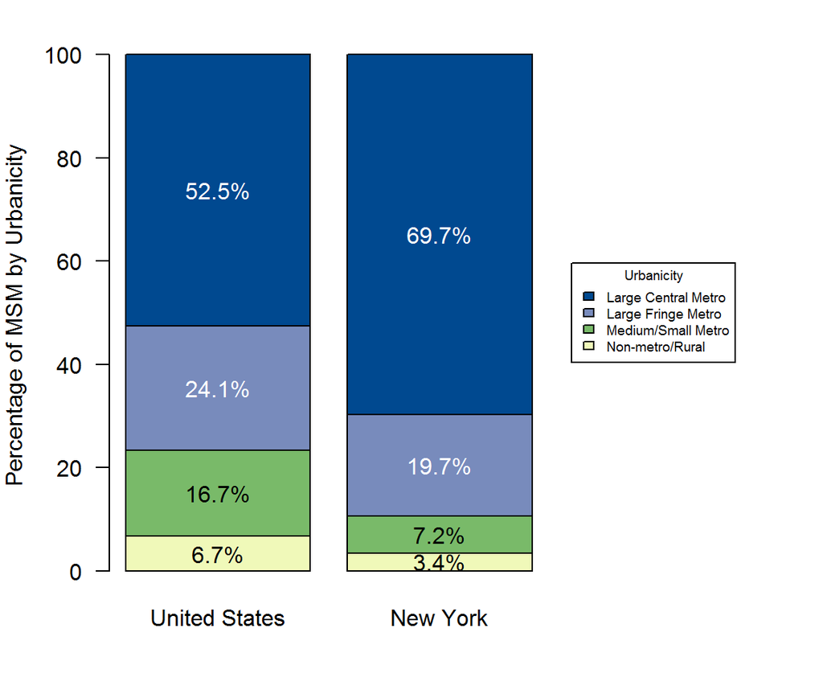

### MSM in New York Counties

Among counties or county-equivalent areas in New York, New York County had the largest population of MSM at 87,555, representing 23.6% of all MSM in the state. New York County also had the highest percentage of MSM among adult men in New York at 13.8%. This was greater than the percentage for New York as a whole, which was 5.1% of adult men.

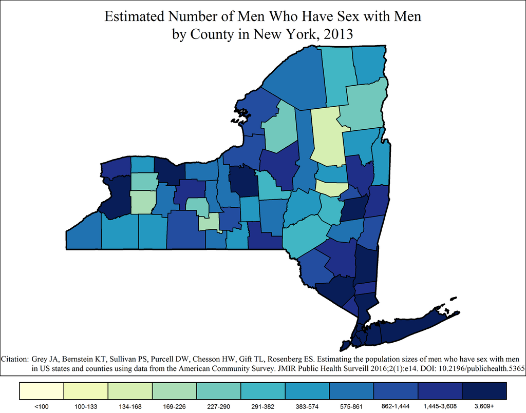

Note: Range cutpoints for the map are based on the distribution of MSM among all counties in the United States.

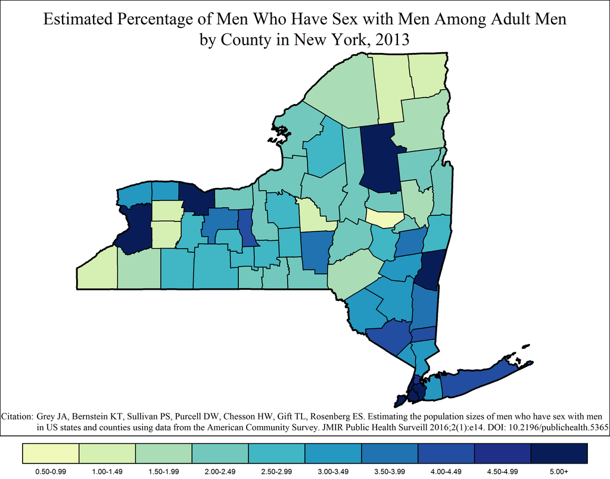

### MSM in New York Metropolitan Statistical Areas

#### New York-Newark-Jersey City Metropolitan Statistical Area

The New York-Newark-Jersey City MSA overlaps three states: New Jersey, New York and Pennsylvania. The New York portion of the MSA had the largest metropolitan population of MSM in New York at 290,535, or 78.3% of all MSM in the state and 73.1% of the 397,399 MSM in the MSA. Of the 4,821,021 adult men in the New York part of New York-Newark-Jersey City, an estimated 6.0% were MSM. This was greater than the percentage of MSM among adult men in the MSA as a whole, which was 5.5% of adult men (397,399 out of 7,239,158).

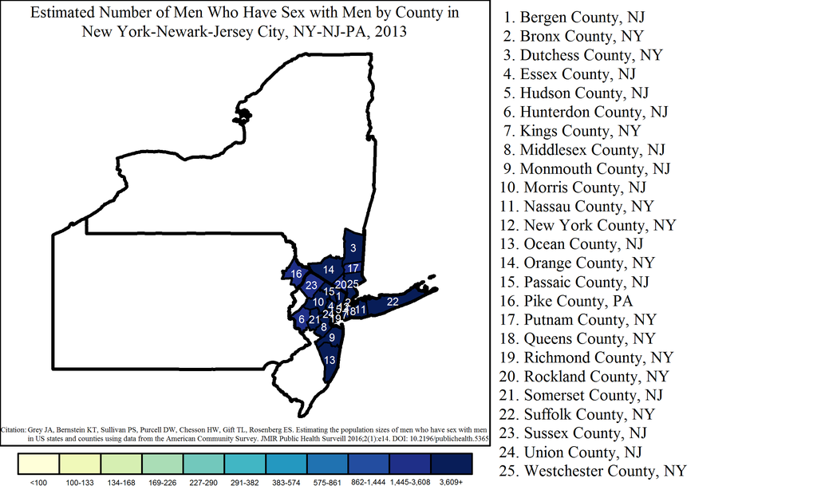

Note: Range cutpoints for the map are based on the distribution of MSM among all counties in the United States.

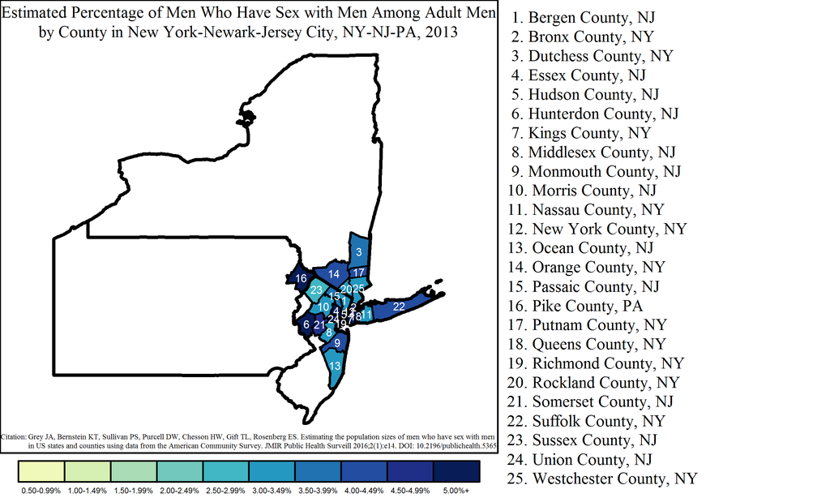

#### Buffalo-Cheektowaga-Niagara Falls Metropolitan Statistical Area

The Buffalo-Cheektowaga-Niagara Falls MSA had a population of 21,471 MSM, or 5.8% of all MSM in New York. Of the 425,533 adult men in Buffalo-Cheektowaga-Niagara Falls, an estimated 5.0% were MSM.

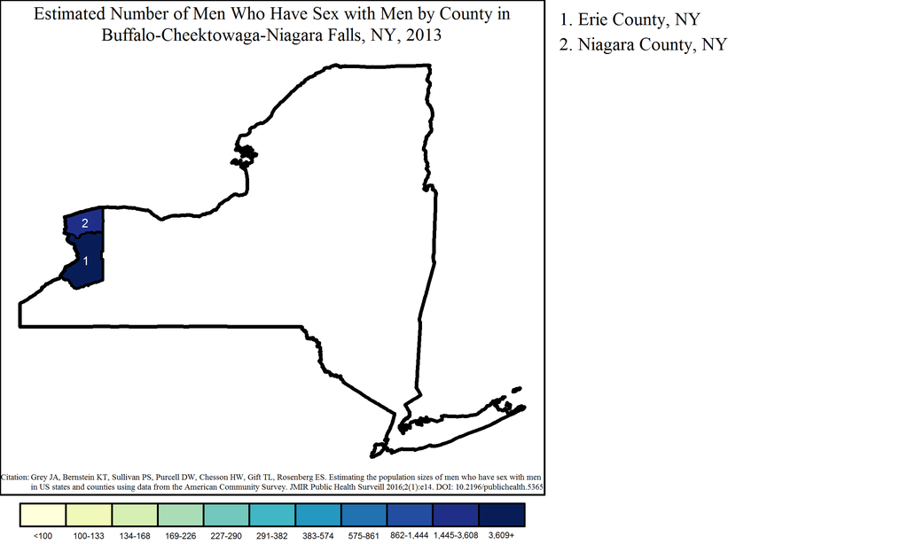

Note: Range cutpoints for the map are based on the distribution of MSM among all counties in the United States.

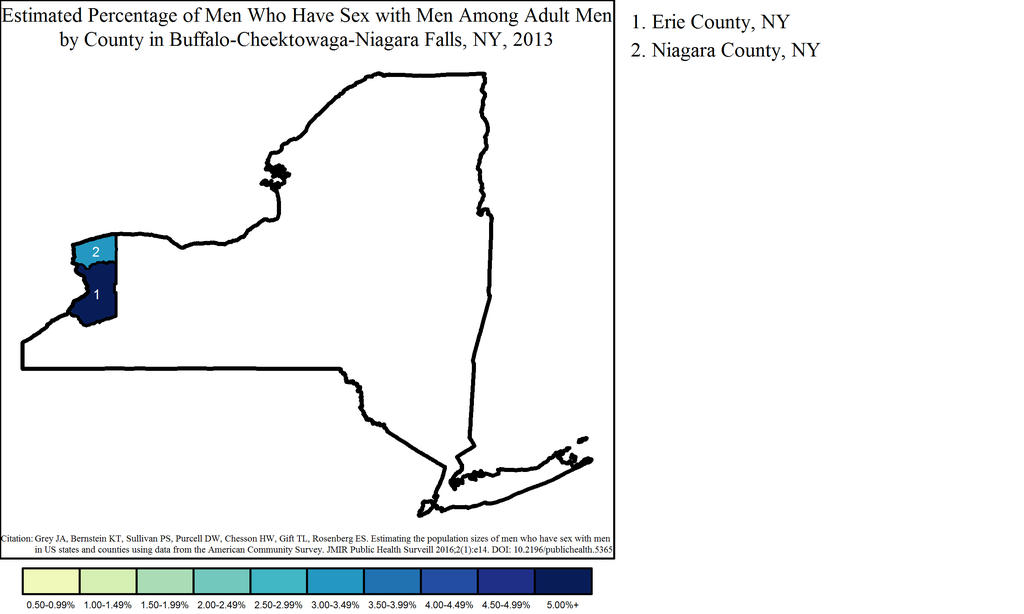

#### Rochester Metropolitan Statistical Area

The Rochester MSA had a population of 19,769 MSM, or 5.3% of all MSM in New York. Of the 403,423 adult men in Rochester, an estimated 4.9% were MSM.

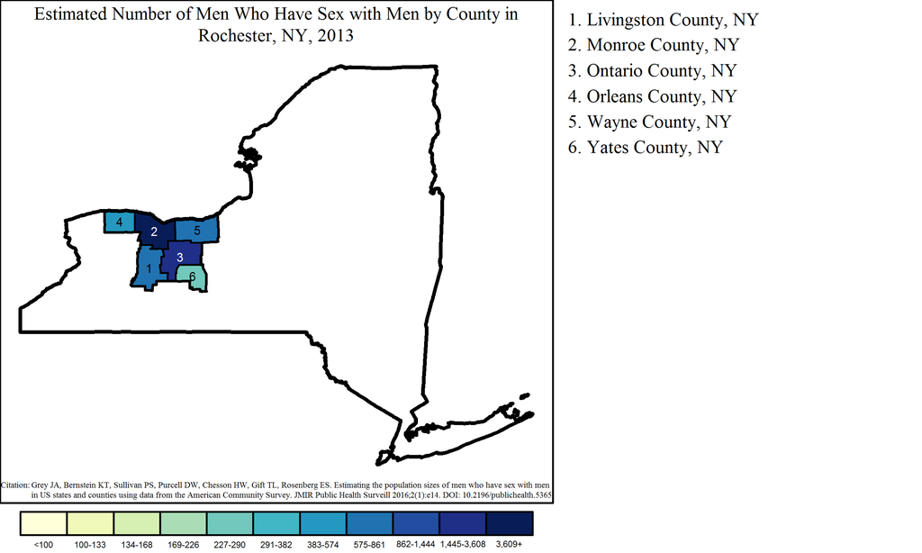

Note: Range cutpoints for the map are based on the distribution of MSM among all counties in the United States.

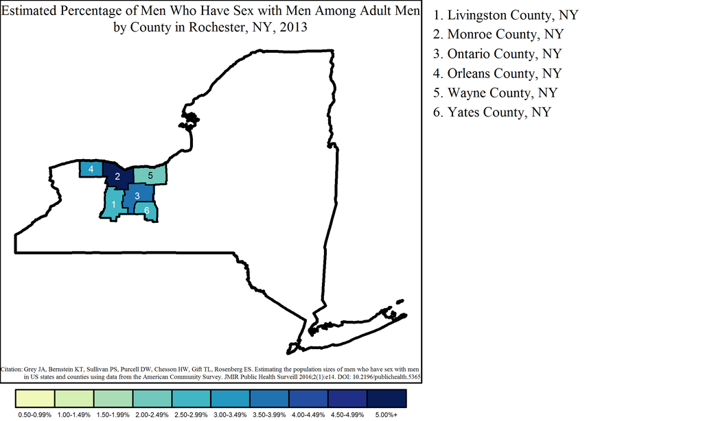

#### Albany-Schenectady-Troy Metropolitan Statistical Area

The Albany-Schenectady-Troy MSA had a population of 9,412 MSM, or 2.5% of all MSM in New York. Of the 332,702 adult men in Albany-Schenectady-Troy, an estimated 2.8% were MSM.

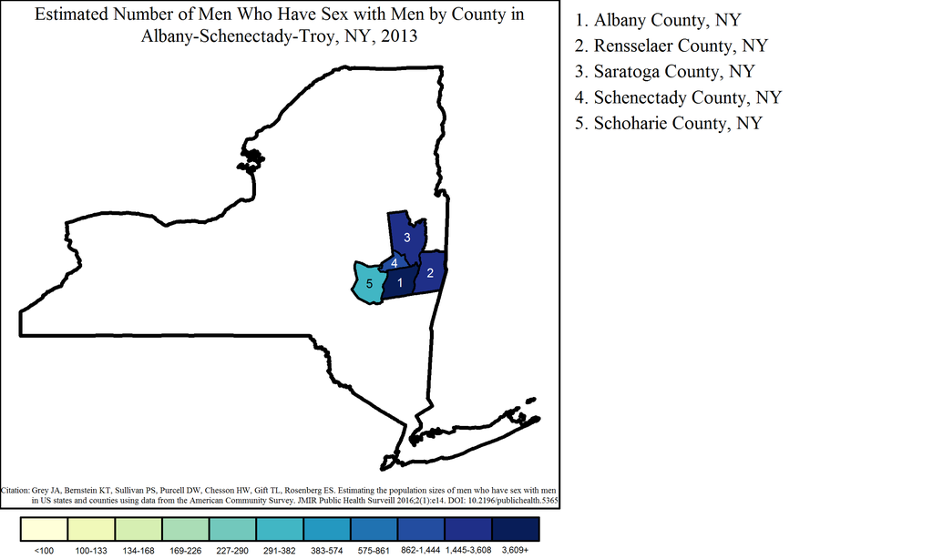

Note: Range cutpoints for the map are based on the distribution of MSM among all counties in the United States.

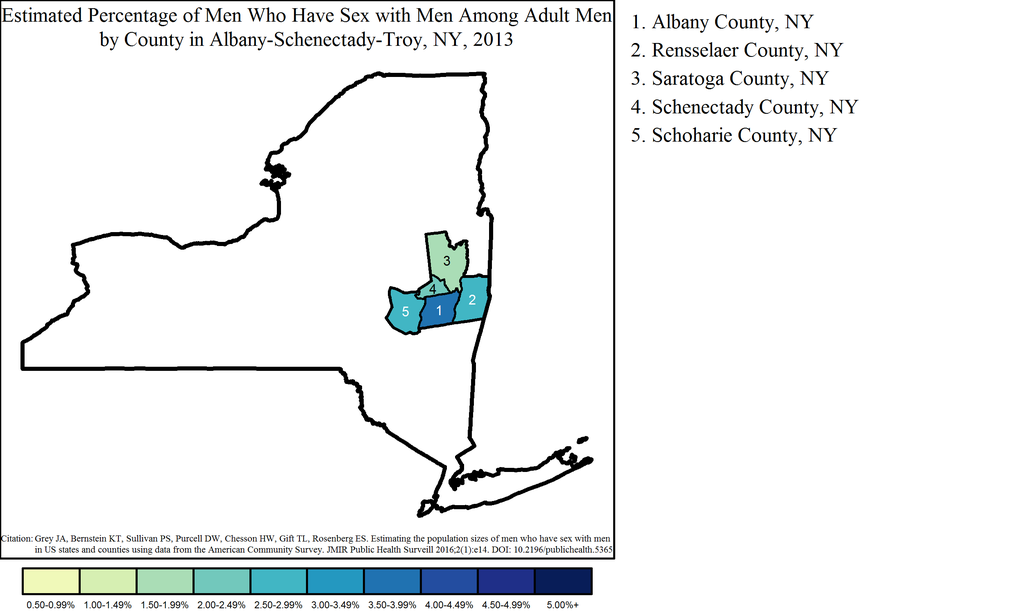

#### Syracuse Metropolitan Statistical Area

The Syracuse MSA had a population of 6,015 MSM, or 1.6% of all MSM in New York. Of the 245,982 adult men in Syracuse, an estimated 2.4% were MSM.

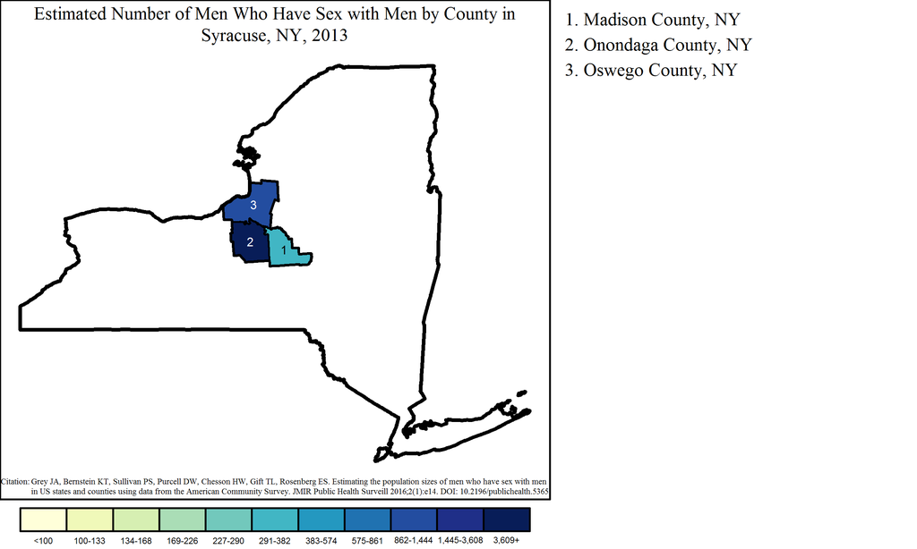

Note: Range cutpoints for the map are based on the distribution of MSM among all counties in the United States.

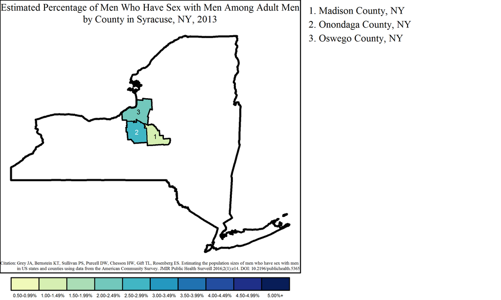

#### Utica-Rome Metropolitan Statistical Area

The Utica-Rome MSA had a population of 2,784 MSM, or 0.8% of all MSM in New York. Of the 115,227 adult men in Utica-Rome, an estimated 2.4% were MSM.

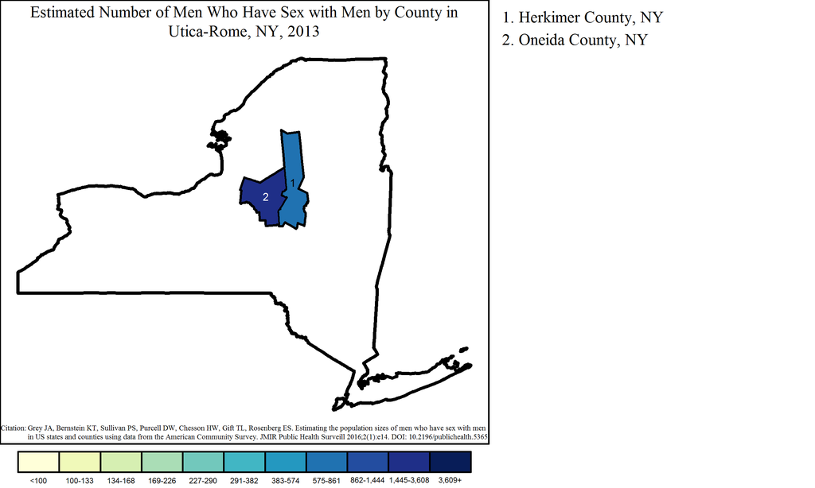

Note: Range cutpoints for the map are based on the distribution of MSM among all counties in the United States.

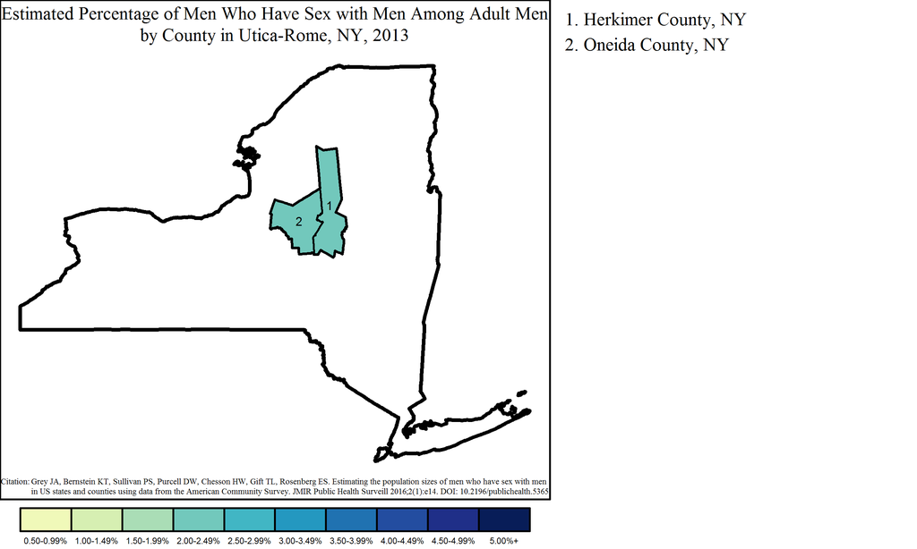

#### Kingston Metropolitan Statistical Area

The Kingston MSA had a population of 2,506 MSM, or 0.7% of all MSM in New York. Of the 72,334 adult men in Kingston, an estimated 3.5% were MSM.

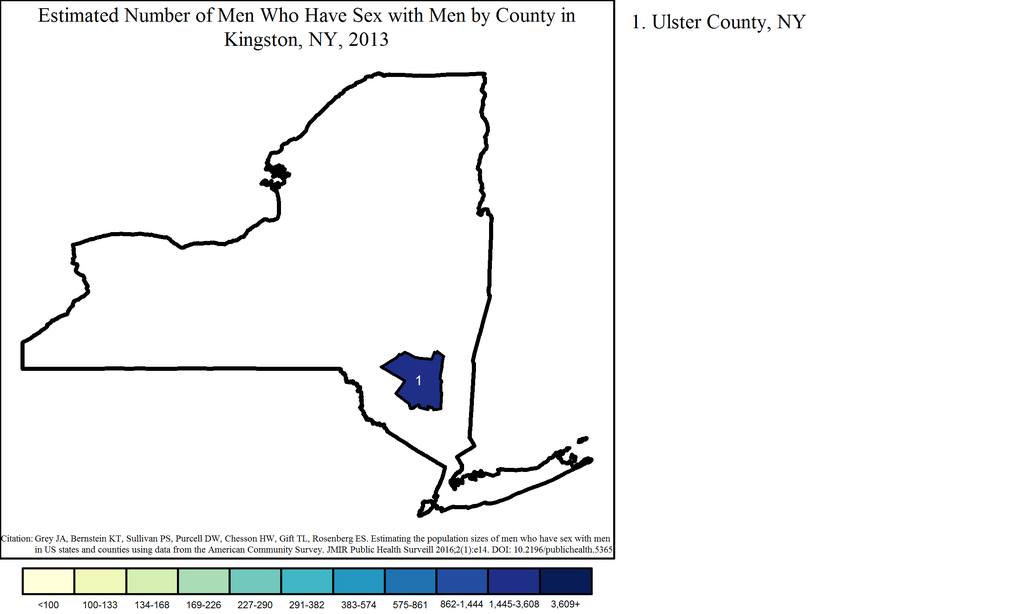

Note: Range cutpoints for the map are based on the distribution of MSM among all counties in the United States.

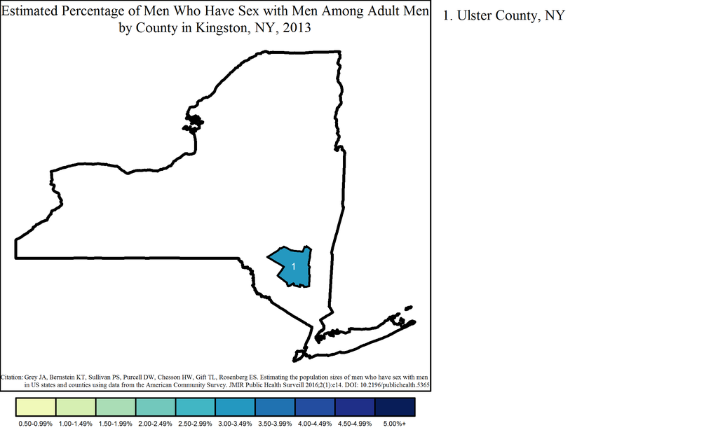

#### Binghamton Metropolitan Statistical Area

The Binghamton MSA had a population of 2,001 MSM, or 0.5% of all MSM in New York. Of the 96,318 adult men in Binghamton, an estimated 2.1% were MSM.

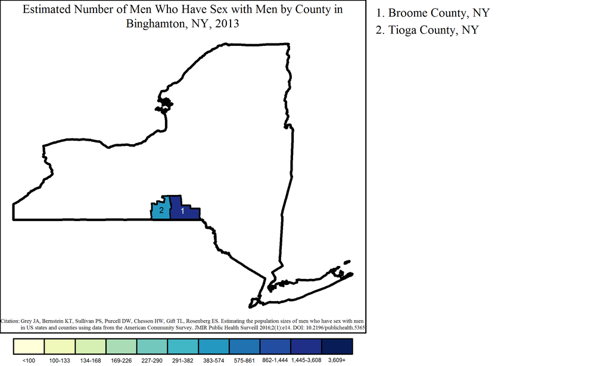

Note: Range cutpoints for the map are based on the distribution of MSM among all counties in the United States.

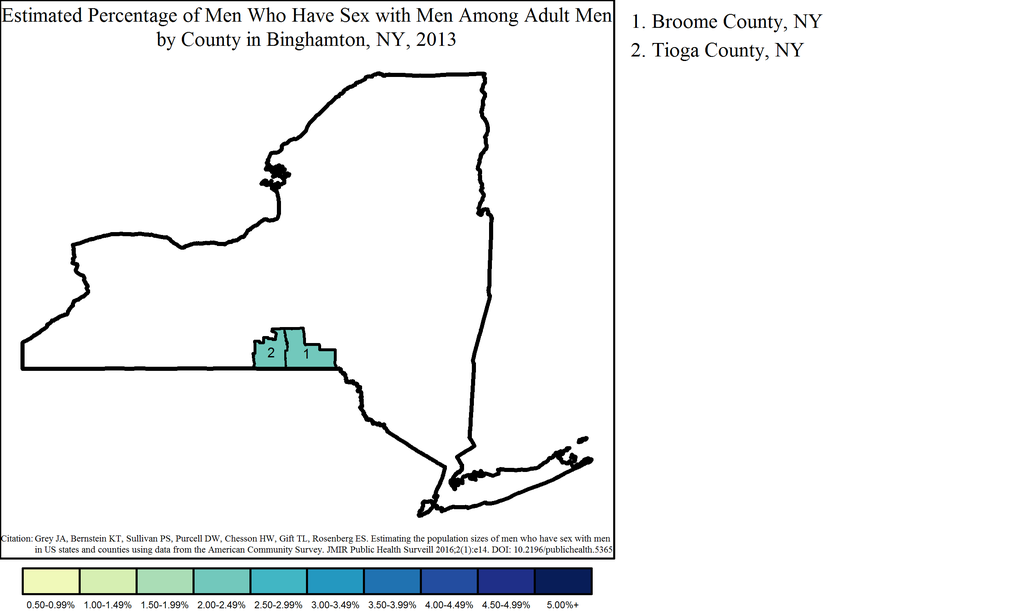

#### Ithaca Metropolitan Statistical Area

The Ithaca MSA had a population of 1,124 MSM, or 0.3% of all MSM in New York. Of the 41,791 adult men in Ithaca, an estimated 2.7% were MSM.

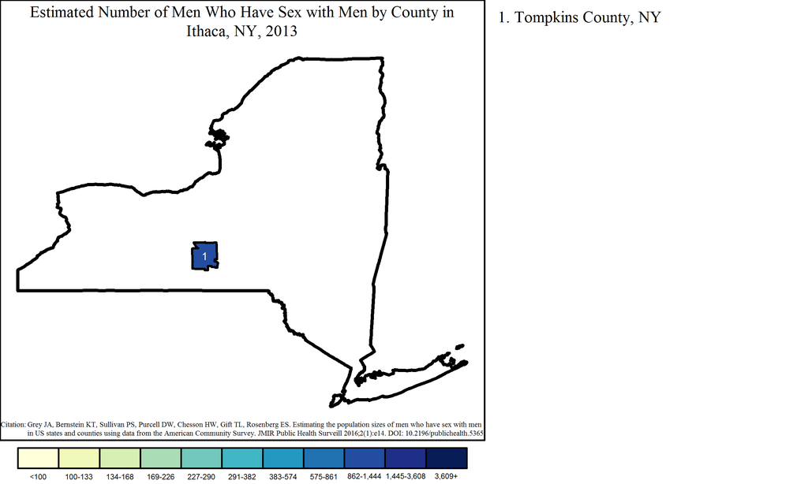

Note: Range cutpoints for the map are based on the distribution of MSM among all counties in the United States.

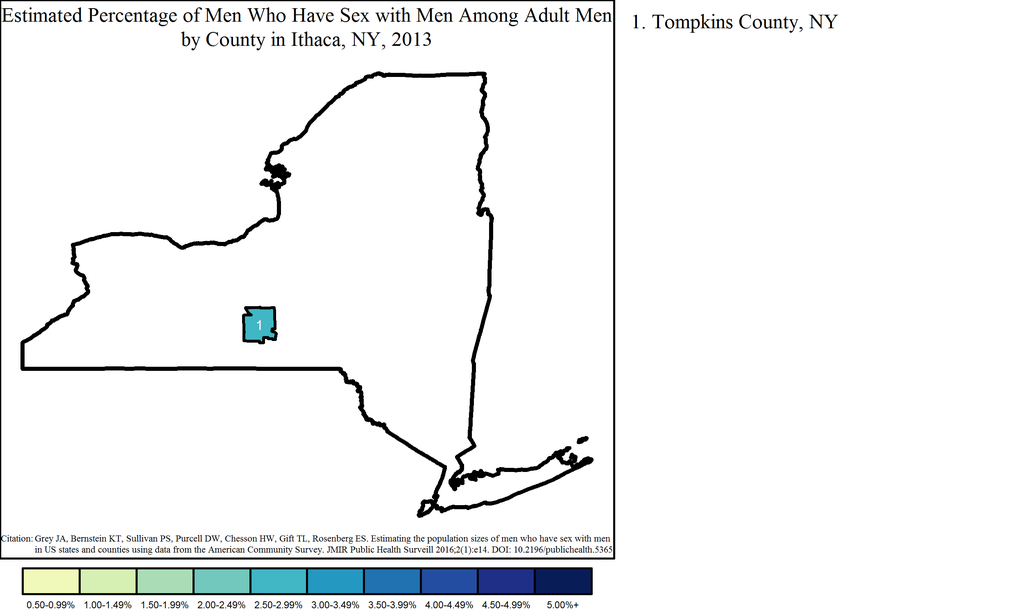

#### Glens Falls Metropolitan Statistical Area

The Glens Falls MSA had a population of 1,085 MSM, or 0.3% of all MSM in New York. Of the 51,174 adult men in Glens Falls, an estimated 2.1% were MSM.

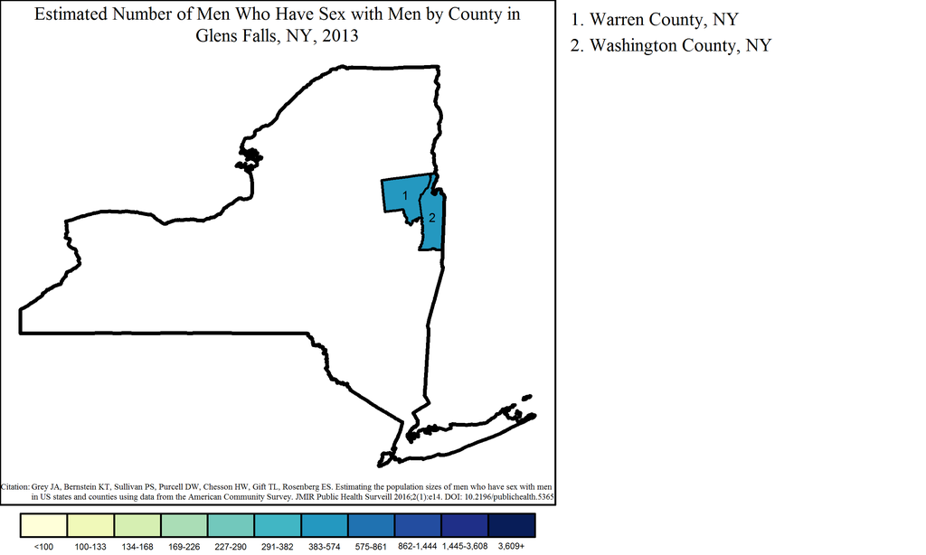

Note: Range cutpoints for the map are based on the distribution of MSM among all counties in the United States.

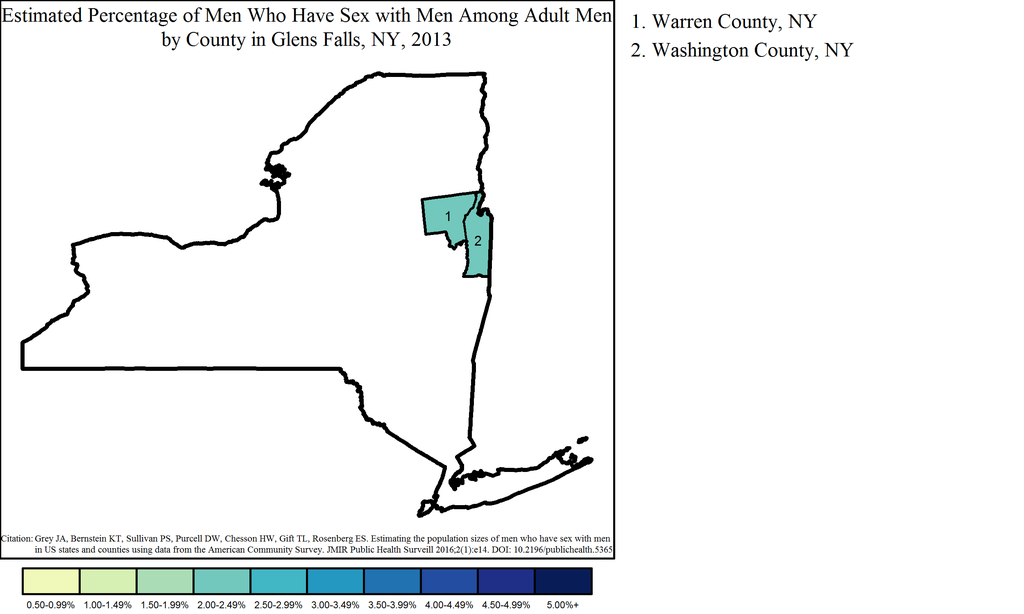

#### Watertown-Fort Drum Metropolitan Statistical Area

The Watertown-Fort Drum MSA had a population of 1,074 MSM, or 0.3% of all MSM in New York. Of the 45,638 adult men in Watertown-Fort Drum, an estimated 2.4% were MSM.

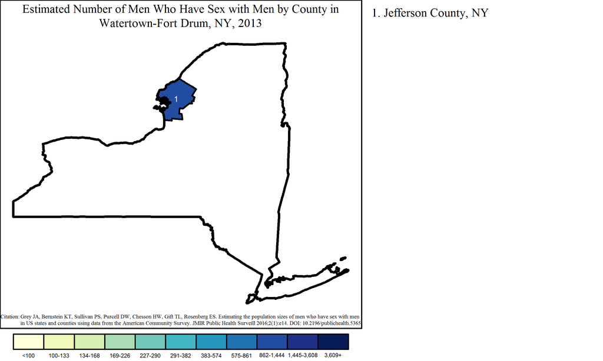

Note: Range cutpoints for the map are based on the distribution of MSM among all counties in the United States.

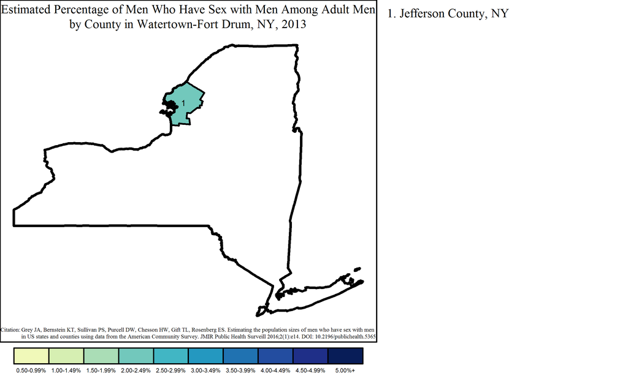

#### Elmira Metropolitan Statistical Area

The Elmira MSA had a population of 726 MSM, or 0.2% of all MSM in New York. Of the 34,142 adult men in Elmira, an estimated 2.1% were MSM.

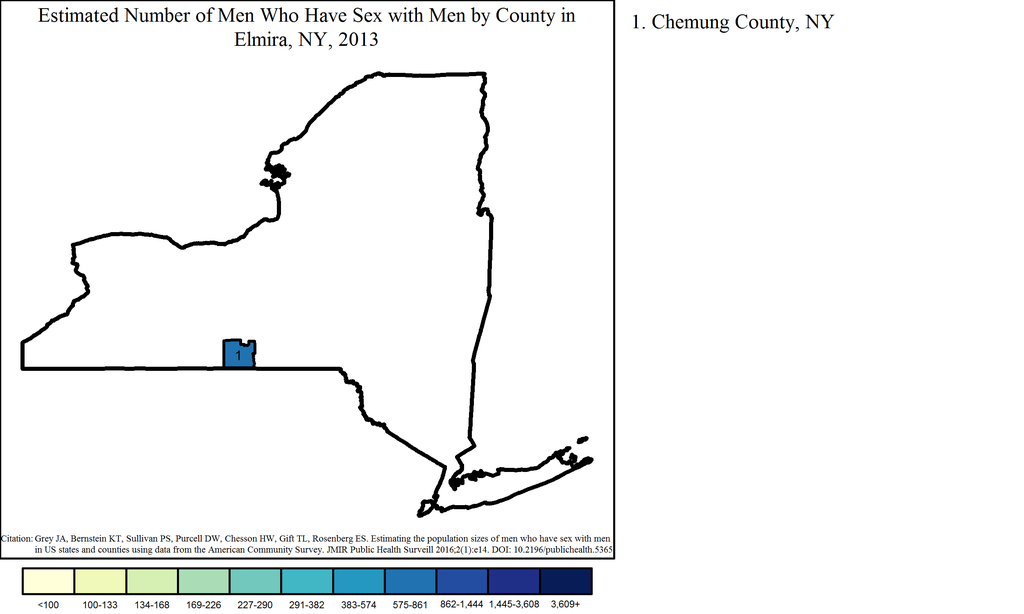

Note: Range cutpoints for the map are based on the distribution of MSM among all counties in the United States.

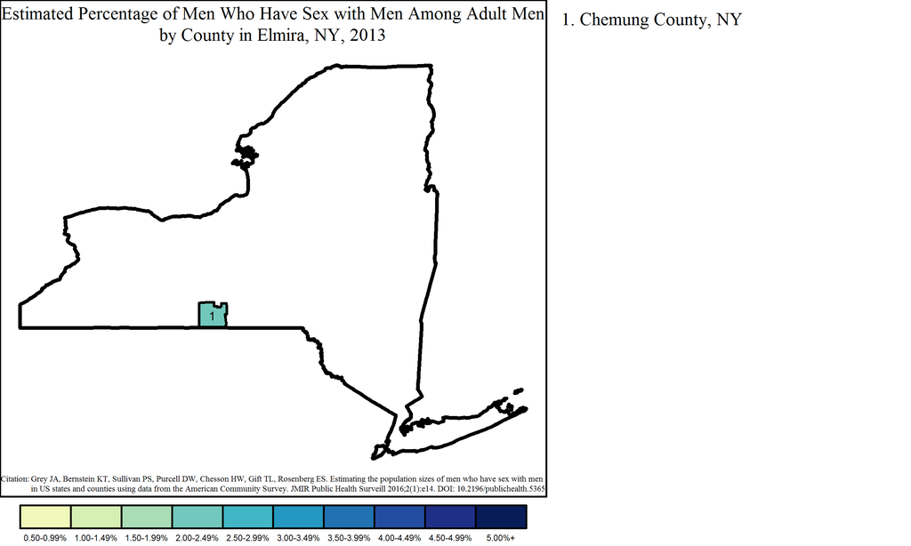